# Simulating from the Null

### Simulating From the Null Hypothesis

Load in the data below, and follow the questions to assist with answering the quiz questions below.

In the previous lesson on confidence intervals, we saw how we could simulate a sampling distribution for a statistic by bootstrapping our sample data. Alternatively, in hypothesis testing, we could simulate a sampling distribution from the null hypothesis using characteristics that would be true if our data were to have come from the null.

**If you get stuck, notice there is a solution notebook available by pushing the orange jupyter icon in the top left!**

```python
import pandas as pd
import numpy as np
import matplotlib.pyplot as plt

%matplotlib inline
np.random.seed(42)

full_data = pd.read_csv('coffee_dataset.csv')
sample_data = full_data.sample(200)
```

`1.` If you were interested in if the average height for coffee drinkers is the same as for non-coffee drinkers, what would the null and alternative be? Place them in the cell below, and use your answer to answer the first quiz question below.

H0: avg_height_coff - avg_height_nocoff = 0

H1: avg_height_coff - avg_height_nocoff != 0

`2.` If you were interested in if the average height for coffee drinkers is less than non-coffee drinkers, what would the null and alternative be? Place them in the cell below, and use your answer to answer the second quiz question below.

H0: avg_height_coff - avg_height_nocoff >= 0

H1: avg_height_coff - avg_height_nocoff < 0

`3.` For 10,000 iterations: bootstrap the sample data, calculate the mean height for coffee drinkers and non-coffee drinkers, and calculate the difference in means for each sample. You will want to have three arrays at the end of the iterations - one for each mean and one for the difference in means. Use the results of your sampling distribution, to answer the third quiz question below.

```python
coff_means, nocoff_means, diff_means = [], [], []
for _ in range(10000):
    bootsample = sample_data.sample(200, replace=True)
    mean_coff = bootsample[bootsample['drinks_coffee'] == True]['height'].mean()
    mean_nocoff = bootsample[bootsample['drinks_coffee'] == False]['height'].mean()
    mean_diff = mean_coff - mean_nocoff
    coff_means.append(mean_coff)
    nocoff_means.append(mean_nocoff)
    diff_means.append(mean_diff)
```

```python
np.std(nocoff_means)
```

```
0.40512631277475264
```

```python
np.std(coff_means)
```

```
0.24073763373473
```

```python
np.std(diff_means)
```

```
0.4698091074387147
```

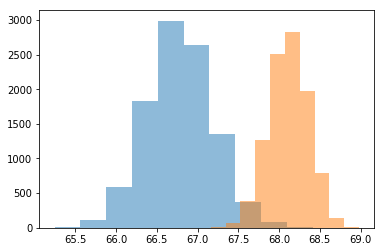

```python
plt.hist(nocoff_means, alpha=0.5)
plt.hist(coff_means, alpha=0.5);
```

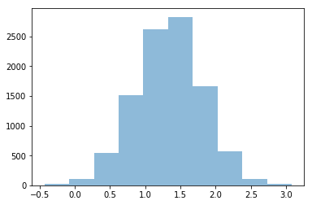

```python
plt.hist(diff_means, alpha=0.5);
```

The shape of each of the sampling distributions comes out to be normal owing to the Central Limit Theorem.

`4.` Now, use your observed sampling distribution for the difference in means and [the docs](https://docs.scipy.org/doc/numpy-1.13.0/reference/generated/numpy.random.normal.html) to simulate what you would expect the sampling distribution to be if the null hypothesis is true. You can do this be recentering your distribution at zero. Also, calculate the observed sample mean difference in `sample_data`. Use your solutions to answer the last questions in the quiz below.

```python
null_vals = np.random.normal(0, np.std(diff_means), 10000)
```

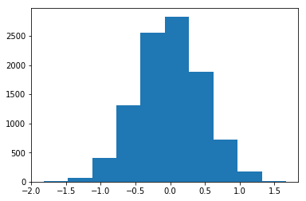

```python
plt.hist(null_vals);
```